# Snippet from Data Science assignment

Emil Frej Brunbjerg (202105405)

Last update: 2022-01-04-

> Does all values in `beer_reviews$beer_id` exist in `beer_types$beer_id` and vice versa? Does all values in `beer_types$brewery_id` exist in `brewery$brewery_id` and vice versa? Make an appropriate join to combine all tibbles into one tibble (call this tibble `beer`), and explain why you choose the join operation(s) you did.

Firstly I import beer_reviews.csv, beer_type.csv, and brewery.csv.

```r
beer_reviews <- read_csv("beer_reviews.csv")
beer_types <- read_csv("beer_types.csv")
brewery <-  read_csv("brewery.csv")
```

We left_join beer_types with reviews, afterwards with brewery, since beer_types contains all ids that seem to contain relevant information.

```r
beer <- left_join(beer_types,beer_reviews, by="beer_id") %>%
  left_join(brewery, by="brewery_id")
```

> Q2.2 Write a function that replaces `NA`’s in a numeric vector with the mean of all non-NA values in that vector. Then use the function in a for loop to replace all `NA` values in the columns `overall`, `aroma`, `appearence`, `palate`, `taste` and `alchohol` located in `beer` tibble you created in Q2.1.)

I define the function accordingly.

```r
nareplacer <- function(a){
  vector_mean = mean(na.omit(a))
  for (i in 1:length(a)){
    if (is.na(a[i]) == T){
      a[i] <- vector_mean
    }
  }
return(a)
}
```

We use the function to change the NAs in the given columns.

```r
for(i in 4:10){
  beer[, i] <- nareplacer(beer[[i]])
}
```

We check if there are any NAs remaning in the columns.

```r
any(is.na(beer[,4:10]))
```

```
## [1] FALSE
```

We conclude that the function has at the very least replaced all NAs.

> Q3.1 If you should recommend a brewery to a friend, which brewery would you recommend and which brewery would you not recommend (base your answer on the breweries in the `beer` tibble)?

This seems to be a simple question, however, there are a number of considerations to make. Immediately, one could try to calculate the mean overall score for all breweries and choose top and bottom scoring breweries.

I group_by brewery and calculate a mean score for each. Afterwards I sort the scores in descending order.

```r
brewery_mean_scores <- group_by(beer, brewery_name) %>%
  summarise(
    mean_score = mean(overall)
  )
brewery_mean_scores %>% arrange(desc(mean_score)) %>% head() %>%
  knitr::kable()
```

| brewery_name | mean_score |
| --- | --- |
| Brauerei Heller-Trum / Schlenkerla | 4.5 |
| Brauhaus Lemke | 4.5 |
| Consorcio Cervecero De Baja California ( La Taberna TJ ) | 4.5 |
| Grumpy’s Brewhaus | 4.5 |
| HopCat | 4.5 |
| Outer Banks Brewing Station | 4.5 |

There are 8 breweries scoring equally well. Since we are being asked to recommend a brewery to a friend, I would be rather be conservative and recommend something I’m confident my friend would enjoy rather than recommend something with a chance to be spectacular.

Therefore, to further narrow down the options we could consider the number of reviews for each of brewery. Due to the law of great numbers, a larger number of observations/reviews would equal a better estimate of the true population mean, if such a thing exists for the perception of how good a beer is. We count the number of reviews, and use this information to construct confidence intervals for the mean overall score. I arbitrarily set the significance level to 95% and assume that scores are normally distributed. I have filtered away breweries with $SD = 0$, since these were resulting in lower and upper bounds being equal to the sample mean, and seemed unlikely to happen for any brewery with more than a couple reviews.

```r
alpha = 0.05

Review_scores <- group_by(beer, brewery_name)  %>%
  summarise(
    n_obs = n(),
    sample_sd = sd(overall),
    mean_overall = mean(overall),
    lower_95_sig = mean_overall - qt(1-(alpha/2), n_obs - 1) * sample_sd / sqrt(n_obs),
    upper_95_sig =  mean_overall + qt(1-(alpha/2), n_obs - 1) * sample_sd / sqrt(n_obs)
  )

Review_scores <- filter(Review_scores, sample_sd > 0)
slice_max(Review_scores,lower_95_sig)
```

```
## # A tibble: 1 × 6
##   brewery_name             n_obs sample_sd mean_overall lower_95_sig upper_95_sig
##   <chr>                    <int>     <dbl>        <dbl>        <dbl>        <dbl>
## 1 East End Brewing Company    24     0.510         4.27         4.06         4.49
```

I am also getting NAs for all single observation breweries. If we are going for a safe pick, it doesn’t seem to matter to include these, since single observations don’t contribute much information anyway. Therefore I slice the top lower bound estimate and pick the “East End Brewing Company” as my recommendation. I slice the lowest higher bound estimate for my anti-recommendation.

```r
slice_min(Review_scores,upper_95_sig)
```

```
## # A tibble: 1 × 6
##   brewery_name            n_obs sample_sd mean_overall lower_95_sig upper_95_sig
##   <chr>                   <int>     <dbl>        <dbl>        <dbl>        <dbl>
## 1 Guangzhou Zhujiang Bre…     7     0.556         2.36         1.84         2.87
```

And I find that the Guangzhou Zhujiang Brewery Co. Ltd. is the worst scoring brewery.

> Q3.2 If the beer-tasters did not give a rating on the `overall` rating, would the beer-taster average of the other ratings be a good substitute for the overall score?

I reconstitute the beer dataframe with all the NAs.

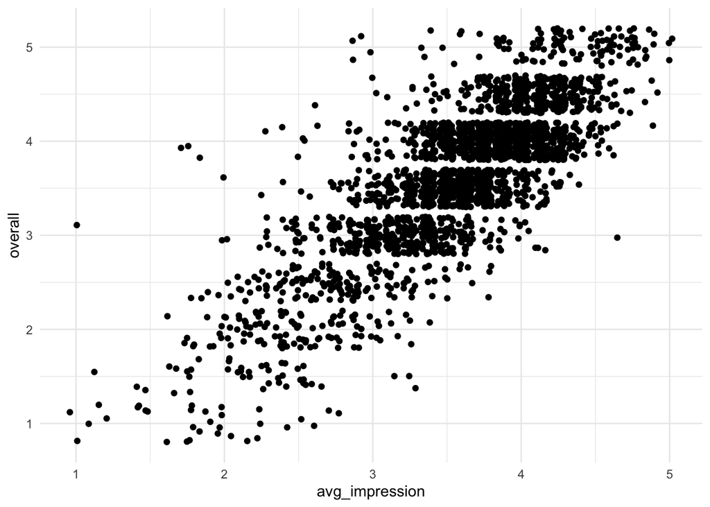

```r
beer <- left_join(beer_types,beer_reviews, by="beer_id") %>%
  left_join(brewery, by="brewery_id") %>%
  na.omit() %>%
  rowwise() %>%
  mutate(
    avg_impression = (aroma + appearance + palate + taste) / 4
  )

beer %>%
  ggplot(aes(x = avg_impression, y = overall)) +
  geom_jitter() +
  theme_minimal()
```

From this plot it seems that there is a linear relationship between the avg_impression (average of the other ratings) and overall. Therefore it seems to be a fair compromise when the overall score is missing. We could use this improved version of the review scores to make a better recommendation.